# Smart Documentation Generator - Analysis Report

Generated by R Analytics

2026-03-14

## Executive Summary

This report provides a comprehensive analysis of the code base and the documentation generated by the Smart Documentation Generator. The tool analyzed 5 source files, containing 6 functions and 1 classes.

## 1. File Summary

The table below shows all source files in the project, along with their function and class counts.

| File | Type | Functions | Classes | Total Items |
| --- | --- | --- | --- | --- |
| MyClass.h | h | 1 | 1 | 2 |
| main.cpp | cpp | 2 | 0 | 2 |
| utils.h | h | 1 | 0 | 1 |
| utils.cpp | cpp | 1 | 0 | 1 |
| MyClass.cpp | cpp | 1 | 0 | 1 |

## 2. Code Structure Analysis

### 2.1 Function Distribution

The bar chart below shows the distribution of functions across all source files.

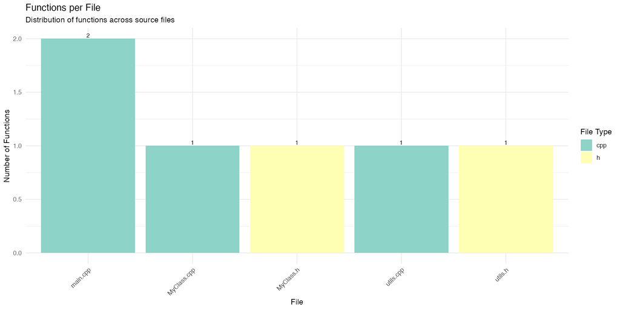

Functions per File

### 2.2 File Type Distribution

This pie chart illustrates the distribution of different file types in the codebase.

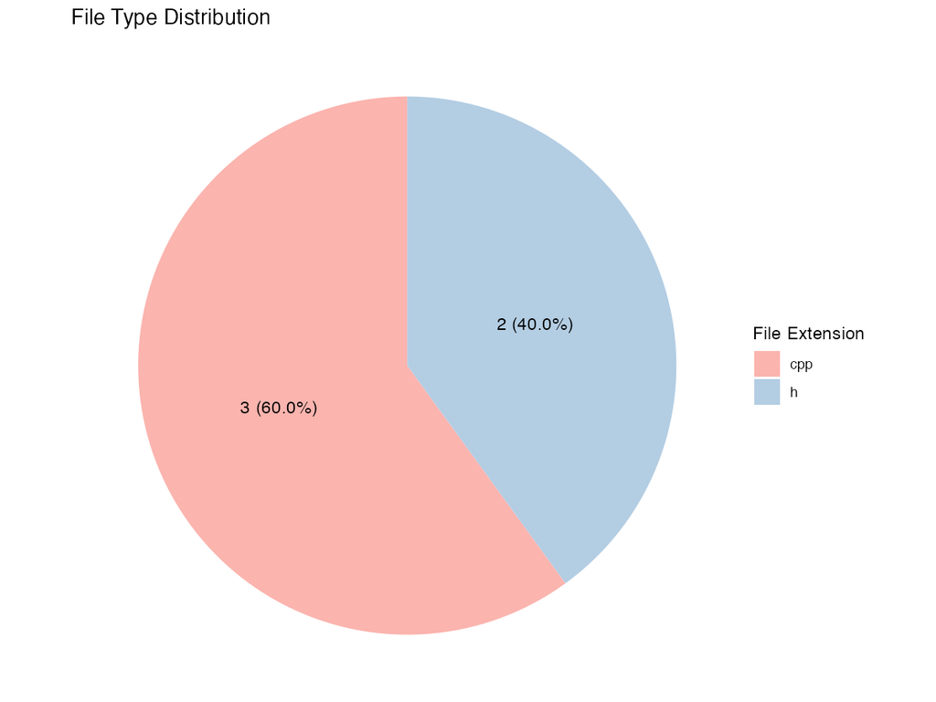

File Types

### 2.3 Function Count Distribution

The histogram shows how many files contain specific numbers of functions, helping identify code complexity patterns.

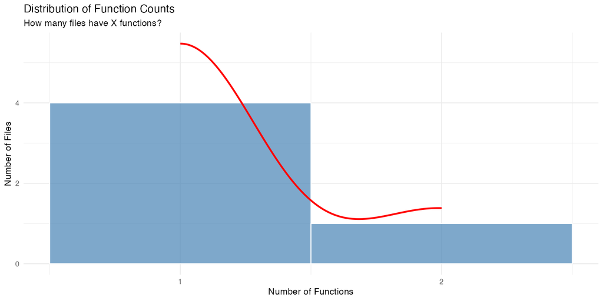

Function Count Histogram

## 3. Documentation Coverage Analysis

### 3.1 Detailed Statistics

Detailed Documentation Statistics

| Metric | Value |
| --- | --- |
| Total Files | 5 |
| Files with Docs | 5 |
| Total Functions | 6 |
| Functions Documented | 6 |
| Total Classes | 1 |
| Classes Documented | 1 |
| Diagrams Generated | 0 |

## 5. Complexity Analysis

### 5.1 Top 10 Most Complex Files

Files with the highest total number of functions and classes (potential complexity hotspots):

Top 10 Most Complex Files

| File | Type | Functions | Classes | Total Items |
| --- | --- | --- | --- | --- |
| MyClass.h | h | 1 | 1 | 2 |
| main.cpp | cpp | 2 | 0 | 2 |
| utils.h | h | 1 | 0 | 1 |
| utils.cpp | cpp | 1 | 0 | 1 |
| MyClass.cpp | cpp | 1 | 0 | 1 |

### 5.2 Files with No Functions

Files that might be headers, resources, or need investigation:

```
## *All files contain at least one function.*
```

## 6. Recommendations

Based on the analysis, here are some recommendations:

```
## - **Review complex files**: 2 files have unusually high complexity (≥2 items). Consider refactoring.
## - **File type consistency**: cpp files dominate (60%). Ensure consistent coding standards.
```

## 7. Appendix

### 7.1 Raw Data Access

The complete analysis data is available in JSON format:

- `code_analysis.json` - Original code structure data from C++ parser
- `statistics.json` - Documentation statistics from Python generator

### 7.2 Generation Information

```
## - **Report generated:** 2026-03-14 16:02:47.406266
```

```
##
## - **R version:** R version 4.5.1 (2025-06-13)
```

```
##
## - **Packages used:** jsonlite, ggplot2, dplyr, plotly, DT, knitr
```

Report generated automatically by the Smart Documentation Generator R Analytics module.